# Reproducibility Report for MA145

Steven Kambouris

18/09/2021

```r
knitr::opts_chunk$set(echo = TRUE,
                      include = TRUE)
```

# Reproducing result from

Moore, F. R., Shuker, D. M., & Dougherty, L. (2016). Stress and sexual signaling: A systematic review and meta-analysis. *Behavioral Ecology*, *27*(2), 363–371. https://doi.org/10.1093/beheco/arv195

# Result to be reproduced

> Across all effect sizes there was no significant correlation between stress levels and the degree of secondary sexual signaling (intercept-only MCMCglmm; posterior mean = −0.08, LHPD = −0.22, UHPD = 0.03, $k = 118$, $N_{studies} = 38$, $N_{species} = 25$). (Moore et al., 2016, p.366)

```r
orig_result_df <- data.frame(ID = "MA145",
                             source = "original",
                             result_type = "mean",
                             es_type = "Fisher z-transformation of correlation",
                             point_est = -0.08,
                             hpdi_lower = -0.22,
                             hpdi_upper = 0.03,
                             n = 118,
                             n_studies = 38,
                             n_species = 25)

knitr::kable(x = orig_result_df)
```

| ID | source | result_type | es_type | point_est | hpdi_lower | hpdi_upper | n | n_studies | n_species |
| --- | --- | --- | --- | --- | --- | --- | --- | --- | --- |
| MA145 | original | mean | Fisher z-transformation of correlation | -0.08 | -0.22 | 0.03 | 118 | 38 | 25 |

# Details of shared data and code files

The following data and code files were shared as supporting information on the web page for the article (https://academic.oup.com/beheco/article/27/2/363/2196777#supplementary-data):

- arv195_supplementary_data.zip
  - Supplementary_material.docx

There is no licencing information available for these files.

# Applicability of shared data and code files

## Data

The supplementary material consists of a single Microsoft Word document - not a traditional data file format. Inspection of the document revealed that the effect size data used in the meta-analysis was included as a table in the document, in Section 2, “Effect sizes used in final analysis”. To be usable, this data would need to be extracted and formatted into a usable state.

## Code

The supplementary material consists of a single Microsoft Word document - not a traditional code file format. Inspection of the document revealed that the code used to conduct the meta-analysis was included in the document, in Section 4, “R code used for analysis”. To be usable, this code would need to be extracted and placed into a standard text file.

# Set up

```r
# Load packages required for working with original files.
library(here)
# Load custom package for (i) running the source command for specific line
# numbers within a file and (ii) for calculating the percentage error between
# the original and reproduced values.
library(reprohelper)

# Load packages required for data import/cleaning.
library(docxtractr)
library(officer)
```

```r
# The analysis code is "trapped" in the shared supplementary material Word
# document, it needs to be extracted and saved to a text file.

# Import the word document using the officer read_docx function.
word_doc1 <- officer::read_docx(here::here("original",
                                           "Supplementary_material.docx"))

# Summarise the imported Word document, creating a data frame.
word_sum1 <- officer::docx_summary(word_doc1)

# Extract the paragraphs in the Word document that correspond to the analysis
# code.
word_code1 <- word_sum1[word_sum1$doc_index %in% 118:337, "text"]

# Write the extracted code to a separate R script file which can then be
# referred to as a source.
# Write to the current working directory, which is where the session has write
# permission.
cat(word_code1, file = "MA145_code_extracted.R", sep = "\n")

# Clean up the objects created so they don't cause conflicts.
rm(list = c("word_doc1", "word_sum1", "word_code1"))

# Load packages required by the code to run.
# (These packages are loaded in the same order as loaded in the original code
# file.)
library(ape)
library(MCMCglmm)
library(orthopolynom)
library(metafor)
# Set the path to the extracted code file, which is being treated as the
# "original" code, despite the extraction step.
orig_source <- here::here("MA145_code_extracted.R")
```

# Import and clean data

```r
# The effect size data used in the meta-analysis is "trapped" in a table within
# the shared supplementary material Word document. It needs to be extracted and
# formatted into a useable form.

# Read in the Word document using the docxtractr package this time.
Word_doc <- docxtractr::read_docx(here::here("original",
                                             "Supplementary_material.docx"))

# Identify and extract the table containing the effect sizes. It is the table
# with index 3 in the document.
print(docxtractr::docx_tbl_count(Word_doc))
```

```
## [1] 4
```

```r
print(docxtractr::docx_describe_tbls(Word_doc))
```

```
## Word document [/home/rstudio/original/Supplementary_material.docx]
##
## Table 1
##   total cells: 45
##   row count  : 15
##   uniform    : likely!
##   has header : likely! => possibly [Paper, Species, Reason for non-inclusion]
##
## Table 2
##   total cells: 68
##   row count  : 34
##   uniform    : likely!
##   has header : likely! => possibly [Paper, Notes]
##
## Table 3
##   total cells: 1212
##   row count  : 123
##   uniform    : unlikely => found differing cell counts (10, 1) across some rows
##   has header : likely! => possibly [Species, Trait, Sex, N, Stress measure, Covariates, df, Zr, var, Study]
##
## Table 4
##   total cells: 120
##   row count  : 15
##   uniform    : likely!
##   has header : likely! => possibly [Factor, Category, Effect sizes, Studies, Species, Mean r, LHPD, UHPD]
##
## NULL
```

```r
Word_table <- docxtractr::docx_extract_tbl(Word_doc, 3)

# Problem: many cells in the table were merged, and values in merged cells were
# separated by line breaks, which have been removed by the import process.
# Need to restore the line-break separated values to the appropriate row in the
# data table.
Word_table_cleaned <- Word_table


# Drop rows that contain only class/order information, convert these to columns
# instead.
Word_table_cleaned$class <- ""
Word_table_cleaned$order <- ""
Word_table_cleaned[1:16, "class"] <- "Amphibian"
Word_table_cleaned[1:16, "order"] <- "Salientia"
Word_table_cleaned[17:94, "class"] <- "Avian"
Word_table_cleaned[17:35, "order"] <- "Galliforme"
Word_table_cleaned[36:94, "order"] <- "Passeriforme"
Word_table_cleaned[95:103, "class"] <- "Mammalian"
Word_table_cleaned[95:103, "order"] <- "Primate"
Word_table_cleaned[104:121, "class"] <- "Reptilian"
Word_table_cleaned[104:121, "order"] <- "Squamata"

# Get the rows which do not contain the class/order information in the Species
# column - those are empty subheader rows.
non_subheader_rows <- which(!Word_table_cleaned$Species %in% c("Amphibian",
                                                               "Salientia",
                                                               "Avian",
                                                               "Galliforme",
                                                               "Passeriforme",
                                                               "Mammalian",
                                                               "Primate",
                                                               "ReptilianSquamata"))
Word_table_cleaned <- Word_table_cleaned[non_subheader_rows, ]

# Clean Species.
check_species <- unique(Word_table_cleaned$Species)

Word_table_cleaned[Word_table_cleaned$Species == check_species[3],
                   "Species"] <- "Great plains toad (Bufo cognatus)"
Word_table_cleaned[Word_table_cleaned$Species == check_species[5],
                   "Species"] <- "Smith frog (Hypiboas faber)"
Word_table_cleaned[Word_table_cleaned$Species == check_species[6],
                   "Species"] <- "Green tree frog (Litoria caerulea)"
Word_table_cleaned[Word_table_cleaned$Species == check_species[7],
                   "Species"] <- "Red legged partridge (Alectoris rufa)"
Word_table_cleaned[Word_table_cleaned$Species == check_species[9],
                   "Species"] <- "Grey partridge (Perdix perdix)"
Word_table_cleaned[Word_table_cleaned$Species == check_species[10],
                   "Species"] <- "Red junglefowl (Gallus gallus)"
Word_table_cleaned[Word_table_cleaned$Species == check_species[11],
                   "Species"] <- "Red grouse (Lagopus lagopus scoticus)"
Word_table_cleaned[Word_table_cleaned$Species == check_species[12],
                   "Species"] <- "Northern cardinal (Cardinalis cardinalis)"
Word_table_cleaned[Word_table_cleaned$Species == check_species[14],
                   "Species"] <- "House finch (Carpodacus mexicanus)"
Word_table_cleaned[Word_table_cleaned$Species == check_species[15],
                   "Species"] <- "Red bishop (Euplectes orix)"
Word_table_cleaned[Word_table_cleaned$Species == check_species[16],
                   "Species"] <- "Collared flycatcher (Ficedula albicollis)"
Word_table_cleaned[Word_table_cleaned$Species == check_species[17],
                   "Species"] <- "Pied flycatcher (Ficedula hypoleuca)"
Word_table_cleaned[Word_table_cleaned$Species == check_species[18],
                   "Species"] <- "Barn swallow (Hirundo rusitca)"
Word_table_cleaned[Word_table_cleaned$Species == check_species[19],
                   "Species"] <- "Red backed fairy wren (Malarus melodicus)"
Word_table_cleaned[Word_table_cleaned$Species == check_species[20],
                   "Species"] <- "Song sparrow (Melospiza melodia)"
Word_table_cleaned[Word_table_cleaned$Species == check_species[22],
                   "Species"] <- "Blue tit (Parus caeruleus)"
Word_table_cleaned[Word_table_cleaned$Species == check_species[24],
                   "Species"] <- "Human (Homo sapien)"
Word_table_cleaned[Word_table_cleaned$Species == check_species[28],
                   "Species"] <- "Striped plateau lizard (Sceloporus virgatus)"

# Fill in missing species values.
for (i in 2:114) {
  if (Word_table_cleaned$Species[i] == "") {
    Word_table_cleaned$Species[i] <- Word_table_cleaned$Species[i - 1]
  }
}

# Duplicate some doubled-up rows.
# Row 94 is doubled up.
dupl_row94 <- Word_table_cleaned[94, ]

# Row 112 is doubled up.
dupl_row112 <- Word_table_cleaned[112, ]

# Row 113 is quadrupled up.
dupl_row113 <- Word_table_cleaned[113, ]

# Drop the empty row at the end.
Word_table_cleaned <- Word_table_cleaned[1:113, ]

# Add Row 112 once, and 113 four times to the end of rows 1:112.
Word_table_cleaned <- rbind(Word_table_cleaned[1:112, ],
                            dupl_row112,
                            dupl_row113, dupl_row113, dupl_row113, dupl_row113)

# Add Row 94 once, in the correct location.
Word_table_cleaned <- rbind(Word_table_cleaned[1:94, ],
                            dupl_row94,
                            Word_table_cleaned[95:117, ])

# Clean trait.
Word_table_cleaned[1:4, "Trait"] <- "Adoption of calling strategy"
Word_table_cleaned[24:28, "Trait"] <- "Comb length"
Word_table_cleaned[42:44, "Trait"] <- Word_table_cleaned[42, "Trait"]
Word_table_cleaned[42:44, "Trait"] <- Word_table_cleaned[42, "Trait"]
Word_table_cleaned[45:47, "Trait"] <- Word_table_cleaned[45, "Trait"]
Word_table_cleaned[48:50, "Trait"] <- Word_table_cleaned[48, "Trait"]
Word_table_cleaned[51:53, "Trait"] <- Word_table_cleaned[51, "Trait"]
Word_table_cleaned[54:56, "Trait"] <- Word_table_cleaned[54, "Trait"]
Word_table_cleaned[59:61, "Trait"] <- "Brightness of ventral phaeomelanic plumage"
Word_table_cleaned[63:64, "Trait"] <- "Red and black plumage coverage"
Word_table_cleaned[80:83, "Trait"] <- "Chroma of yellow plumage"
Word_table_cleaned[90:94, "Trait"] <- "Female preference for male faces"
Word_table_cleaned[95, "Trait"] <- "Male preference for female faces"
Word_table_cleaned[113, "Trait"] <- "Size of orange ovulatory throat patch"
Word_table_cleaned[114, "Trait"] <- "Orange colouration of throat patch (principal component)"
Word_table_cleaned[115, "Trait"] <- "Size of orange ovulatory throat patch"
Word_table_cleaned[116, "Trait"] <- "Mean reflectance of throat patch"
Word_table_cleaned[117, "Trait"] <- "Orange colouration of throat patch (principal component 1)"
Word_table_cleaned[118, "Trait"] <- "Orange colouration of throat patch (principal component 2)"

# Clean Sex.
Word_table_cleaned[1:9, "Sex"] <- "M"
Word_table_cleaned[11:17, "Sex"] <- "M"
Word_table_cleaned[18, "Sex"] <- "F"
Word_table_cleaned[21:33, "Sex"] <- "M"
Word_table_cleaned[34:35, "Sex"] <- "F"
Word_table_cleaned[37:61, "Sex"] <- "M"
Word_table_cleaned[63:78, "Sex"] <- "M"
Word_table_cleaned[90:94, "Sex"] <- "M"
Word_table_cleaned[95, "Sex"] <- "F"
Word_table_cleaned[98:112, "Sex"] <- "M"
Word_table_cleaned[113:118, "Sex"] <- "F"

# Clean N.
Word_table_cleaned[11:12, "N"] <- "29"
Word_table_cleaned[13:14, "N"] <- "68"
Word_table_cleaned[15, "N"] <- "30"
Word_table_cleaned[16, "N"] <- "29"
Word_table_cleaned[17, "N"] <- "30"
Word_table_cleaned[18, "N"] <- "20"
Word_table_cleaned[21:23, "N"] <- "48"
Word_table_cleaned[37:39, "N"] <- "31"
Word_table_cleaned[40:41, "N"] <- "52"
Word_table_cleaned[42:56, "N"] <- "23"
Word_table_cleaned[59:61, "N"] <- "90"
Word_table_cleaned[74:77, "N"] <- "24"
Word_table_cleaned[94, "N"] <- "74"
Word_table_cleaned[95, "N"] <- "52"
Word_table_cleaned[99:106, "N"] <- "31"
Word_table_cleaned[107:112, "N"] <- "29"
Word_table_cleaned[113:118, "N"] <- "45"

# Clean Stress.measure.
Word_table_cleaned[1:2, "Stress.measure"] <- "BCORT"
Word_table_cleaned[3:4, "Stress.measure"] <- "ECORT"
Word_table_cleaned[11:12, "Stress.measure"] <- "BCORT"
Word_table_cleaned[13:14, "Stress.measure"] <- "ECORT"
Word_table_cleaned[15:18, "Stress.measure"] <- "H:L"
Word_table_cleaned[24:28, "Stress.measure"] <- "BCORT"
Word_table_cleaned[29:31, "Stress.measure"] <- "FeathCORT"
Word_table_cleaned[32:35, "Stress.measure"] <- "H:L"
Word_table_cleaned[37:39, "Stress.measure"] <- "FeathCORT"
Word_table_cleaned[40:41, "Stress.measure"] <- "H:L"
Word_table_cleaned[57:58, "Stress.measure"] <- "FecCORT"
Word_table_cleaned[65:67, "Stress.measure"] <- "BCORT"
Word_table_cleaned[68:70, "Stress.measure"] <- "PCORT"
Word_table_cleaned[71:73, "Stress.measure"] <- "PCORT-BCORT"
Word_table_cleaned[74:75, "Stress.measure"] <- "BCORT"
Word_table_cleaned[76:77, "Stress.measure"] <- "PCORT"
Word_table_cleaned[90:95, "Stress.measure"] <- "BCORT"
Word_table_cleaned[113:114, "Stress.measure"] <- "BCORT"
Word_table_cleaned[115:118, "Stress.measure"] <- "ECORT"

# Clean Covariates.
Word_table_cleaned[32:35, "Covariates"] <- "Date and time"
Word_table_cleaned[37:39, "Covariates"] <- "Body size"
Word_table_cleaned[57:58, "Covariates"] <- "Date of arrival at breeding grounds body condition HSP60 age"
Word_table_cleaned[59:61, "Covariates"] <- "Site date body mass timing of sunset"
Word_table_cleaned[63:64, "Covariates"] <- "Date and testosterone"
Word_table_cleaned[90, "Covariates"] <- ""
Word_table_cleaned[92:93, "Covariates"] <- "Testosterone"
Word_table_cleaned[107:112, "Covariates"] <- "Moult status colour alleles and number of ingested larvae"
Word_table_cleaned[113:114, "Covariates"] <- "Estradial progesterone testosterone"
Word_table_cleaned[115:118, "Covariates"] <- "Body mass reproductive state"

# Clean df.
Word_table_cleaned[13:14, "df"] <- "68"
Word_table_cleaned[15, "df"] <- "29"
Word_table_cleaned[16, "df"] <- "28"
Word_table_cleaned[17, "df"] <- "29"
Word_table_cleaned[18, "df"] <- "19"
Word_table_cleaned[21:23, "df"] <- "43"
Word_table_cleaned[37:39, "df"] <- "30"
Word_table_cleaned[40:41, "df"] <- "40"
Word_table_cleaned[42:56, "df"] <- "23"
Word_table_cleaned[59:61, "df"] <- "87"
Word_table_cleaned[74:77, "df"] <- "24"
Word_table_cleaned[99:106, "df"] <- "30"
Word_table_cleaned[107:112, "df"] <- "28"
Word_table_cleaned[94, "df"] <- "73"
Word_table_cleaned[95, "df"] <- "52"
Word_table_cleaned[113:114, "df"] <- "45"
Word_table_cleaned[115:118, "df"] <- "42"

# Clean Zr.
Word_table_cleaned[94, "Zr"] <- "-0.172"
Word_table_cleaned[95, "Zr"] <- "-0.405"
Word_table_cleaned[113, "Zr"] <- "-0.427"
Word_table_cleaned[114, "Zr"] <- "-0.47"
Word_table_cleaned[115, "Zr"] <- "-0.253"
Word_table_cleaned[116, "Zr"] <- "0.152"
Word_table_cleaned[117, "Zr"] <- "-0.134"
Word_table_cleaned[118, "Zr"] <- "-0.374"

# Clean var.
Word_table_cleaned[94, "var"] <- "0.014"
Word_table_cleaned[95, "var"] <- "0.02"
Word_table_cleaned[113:118, "var"] <- "0.024"

# Clean Study.
Word_table_cleaned[94, "Study"] <- "Rantala et al. 2012"
Word_table_cleaned[95, "Study"] <- "Rantala et al. 2013"
Word_table_cleaned[113:118, "Study"] <- "Weiss et al. 2013"

# Check for issues with double spacing, or other artifacts preventing the same
# study from having the same value.
check_study <- unique(Word_table_cleaned$Study)
print(length(check_study))
```

```
## [1] 39
```

```r
Word_table_cleaned[which(Word_table_cleaned$Study == "Perez-Rodriguez and  Viñuela 2008"),
                   "Study"] <- "Perez-Rodriguez and Viñuela 2008"

check_study <- unique(Word_table_cleaned$Study)
print(length(check_study))
```

```
## [1] 38
```

```r
# Convert the type of some columns.
Word_table_cleaned$N <- as.integer(Word_table_cleaned$N)
Word_table_cleaned$df <- as.integer(Word_table_cleaned$df)
Word_table_cleaned$Zr <- as.numeric(Word_table_cleaned$Zr)
Word_table_cleaned$var <- as.numeric(Word_table_cleaned$var)

# Recode the species names.
Word_table_cleaned[Word_table_cleaned$Species == "Great plains toad (Bufo cognatus)",
                   "Species"] <- "Bufo_cognatus"
Word_table_cleaned[Word_table_cleaned$Species == "Woodhouse’s toad (Bufo Woodhousii)",
                   "Species"] <- "Bufo_woodhousii"
Word_table_cleaned[Word_table_cleaned$Species == "Smith frog (Hypiboas faber)",
                   "Species"] <- "Hypsiboas_faber"
Word_table_cleaned[Word_table_cleaned$Species == "Green tree frog (Litoria caerulea)",
                   "Species"] <- "Litoria_caerulea"
Word_table_cleaned[Word_table_cleaned$Species == "Red legged partridge (Alectoris rufa)",
                   "Species"] <- "Alectoris_rufa"
Word_table_cleaned[Word_table_cleaned$Species == "Grey partridge (Perdix perdix)",
                   "Species"] <- "Perdix_perdix"
Word_table_cleaned[Word_table_cleaned$Species == "Red junglefowl (Gallus gallus)",
                   "Species"] <- "Gallus_gallus"
Word_table_cleaned[Word_table_cleaned$Species == "Red grouse (Lagopus lagopus scoticus)",
                   "Species"] <- "Lagopus_lagopus"
Word_table_cleaned[Word_table_cleaned$Species == "Northern cardinal (Cardinalis cardinalis)",
                   "Species"] <- "Cardinalis_cardinalis"
Word_table_cleaned[Word_table_cleaned$Species == "Greenfinch (Carduelis chloris)",
                   "Species"] <- "Carduelis_chloris"
Word_table_cleaned[Word_table_cleaned$Species == "House finch (Carpodacus mexicanus)",
                   "Species"] <- "Carpodacus_mexicanus"
Word_table_cleaned[Word_table_cleaned$Species == "Red bishop (Euplectes orix)",
                   "Species"] <- "Euplectes_orix"
Word_table_cleaned[Word_table_cleaned$Species == "Collared flycatcher (Ficedula albicollis)",
                   "Species"] <- "Ficedula_albicollis"
Word_table_cleaned[Word_table_cleaned$Species == "Pied flycatcher (Ficedula hypoleuca)",
                   "Species"] <- "Ficedula_hypoleuca"
Word_table_cleaned[Word_table_cleaned$Species == "Barn swallow (Hirundo rusitca)",
                   "Species"] <- "Hirundo_rustica"
Word_table_cleaned[Word_table_cleaned$Species == "Red backed fairy wren (Malarus melodicus)",
                   "Species"] <- "Malurus_melanocephalus"
Word_table_cleaned[Word_table_cleaned$Species == "Song sparrow (Melospiza melodia)",
                   "Species"] <- "Melospiza_melodia"
Word_table_cleaned[Word_table_cleaned$Species == "Brown headed cow bird (Molothrus ater)",
                   "Species"] <- "Molothrus_ater"
Word_table_cleaned[Word_table_cleaned$Species == "Blue tit (Parus caeruleus)",
                   "Species"] <- "Parus_caeruleus"
Word_table_cleaned[Word_table_cleaned$Species == "Red Winged blackbird (Agelaius phoeniceus)",
                   "Species"] <- "Agelaius_phoeniceus"
Word_table_cleaned[Word_table_cleaned$Species == "Human (Homo sapien)",
                   "Species"] <- "Homo_sapiens"
Word_table_cleaned[Word_table_cleaned$Species == "Mandrill (Madrillus sphinx)",
                   "Species"] <- "Mandrillus_sphinx"
Word_table_cleaned[Word_table_cleaned$Species == "Rock hyrax (Procavia capensis)",
                   "Species"] <- "Procavia_capensis"
Word_table_cleaned[Word_table_cleaned$Species == "Common lizard (Lacerta vivipara)",
                   "Species"] <- "Lacerta_vivipara"
Word_table_cleaned[Word_table_cleaned$Species == "Striped plateau lizard (Sceloporus virgatus)",
                   "Species"] <- "Sceloporus_virgatus"

# Clean up.
rm(list = c("check_species", "check_study", "i", "non_subheader_rows",
            "dupl_row94", "dupl_row112", "dupl_row113", "Word_doc", "Word_table"))

# Create the data object with the name and format expected by the original
# code.
data <- as.data.frame(Word_table_cleaned)
names(data)[names(data) == "Study"] <- "study"
names(data)[names(data) == "Trait"] <- "trait"
names(data)[names(data) == "Species"] <- "species"
names(data)[names(data) == "Zr"] <- "zr"

# Because original data import call would have automatically converted all
# strings to factors, convert all string columns to factors.
data$species <- as.factor(data$species)
data$trait <- as.factor(data$trait)
data$Sex <- as.factor(data$Sex)
data$Stress.measure <- as.factor(data$Stress.measure)
data$Covariates <- as.factor(data$Covariates)
data$study <- as.factor(data$study)
```

# (Re-)run the analysis to reproduce result

```r
# Perform required data formatting.
sourceLines(orig_source, 20, 22)
```

```
##
## > names(data)[names(data) == "trait"] <- "trait_measure"
##
## > data$animal <- as.factor(data$species)
##
## > str(data)
## 'data.frame':    118 obs. of  14 variables:
##  $ species       : Factor w/ 25 levels "Agelaius_phoeniceus",..: 3 4 3 4 3 3 3 3 3 4 ...
##  $ trait_measure : Factor w/ 73 levels "Adoption of calling strategy",..: 1 1 1 1 15 18 16 21 15 72 ...
##  $ Sex           : Factor w/ 2 levels "F","M": 2 2 2 2 2 2 2 2 2 2 ...
##  $ N             : int  44 111 9 9 9 9 9 9 38 293 ...
##  $ Stress measure: chr  "BCORT BCORT" "" "ECORT  ECORT" "" ...
##  $ Covariates    : Factor w/ 16 levels "","Body mass PHA immature erythrocytes and tarsus length",..: 1 1 1 1 1 1 1 1 9 1 ...
##  $ df            : int  43 110 9 9 7 7 7 7 35 293 ...
##  $ zr            : num  0.493 0.187 -1.099 -0.746 -0.488 ...
##  $ var           : num  0.024 0.009 0.167 0.167 0.167 0.167 0.167 0.167 0.03 0.003 ...
##  $ study         : Factor w/ 38 levels "Assis et al. 2012",..: 14 14 15 15 16 16 16 16 16 17 ...
##  $ class         : chr  "Amphibian" "Amphibian" "Amphibian" "Amphibian" ...
##  $ order         : chr  "Salientia" "Salientia" "Salientia" "Salientia" ...
##  $ Stress.measure: Factor w/ 7 levels "BCORT","ECORT",..: 1 1 2 2 NA NA NA NA NA NA ...
##  $ animal        : Factor w/ 25 levels "Agelaius_phoeniceus",..: 3 4 3 4 3 3 3 3 3 4 ...
```

```
##
## > summary.phylo(tree)
##
## Phylogenetic tree: tree
##
##   Number of tips: 25
##   Number of nodes: 24
##   Branch lengths:
##     mean: 2.229167
##     variance: 6.010195
##     distribution summary:
##    Min. 1st Qu.  Median 3rd Qu.    Max.
##       1       1       1       2      10
##   No root edge.
##   First ten tip labels: Melospiza_melodia
##                         Agelaius_phoeniceus
##                         Molothrus_ater
##                         Cardinalis_cardinalis
##                         Carpodacus_mexicanus
##                         Carduelis_chloris
##                         Euplectes_orix
##                         Ficedula_hypoleuca
##                         Ficedula_albicollis
##                         Hirundo_rustica
##   No node labels.
##
## > plot(tree)
```

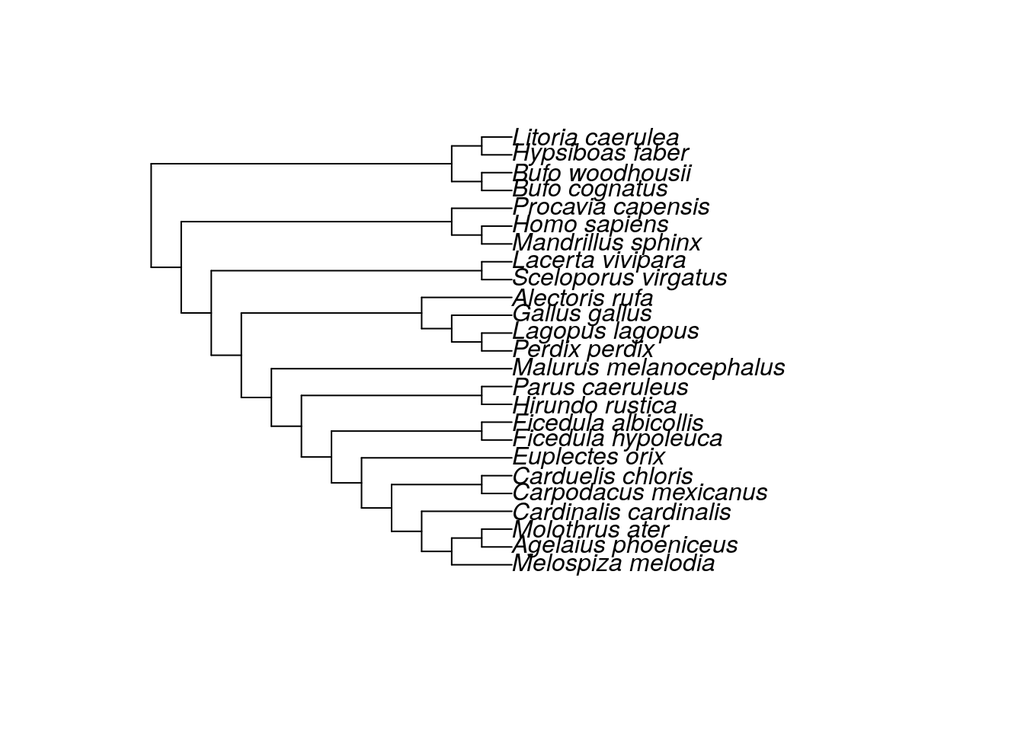

```r
# Import manually created tree file.
tree <- read.tree(file = here::here("original", "MA145_recreated_all_species_cladogram.txt"))

# Check tree file (summarise and plot the tree).
sourceLines(orig_source, 26, 27)
```

```r
# Set priors.
sourceLines(orig_source, 37, 39)
```

```
##
## > prior1 <- list(R = list(V = 1, nu = 0.002), G = list(G1 = list(V = 1,
## +     nu = 0.002)))
##
## > prior2 <- list(R = list(V = 1, nu = 0.002), G = list(G1 = list(V = 1,
## +     nu = 0.002), G2 = list(V = 1, nu = 0.002)))
##
## > prior3 <- list(R = list(V = 1, nu = 0.002), G = list(G1 = list(V = 1,
## +     nu = 0.002), G2 = list(V = 1, nu = 0.002), G3 = list(V = 1,
## +     nu = .... [TRUNCATED]
```

```r
# Set a random seed to ensure reproducibility of results.
set.seed(145)

# Run the three-random-effects model.
# (Use custom code only to set the option verbose=FALSE to make output
# shorter.)
meta2 <- MCMCglmm(zr~1, random= ~study + species + animal, mev=data$var, data=data,
nitt=3000000, thin=2000, burnin=2000000, pr=TRUE, prior=prior3, pedigree=tree, verbose = FALSE)
```

```r
#sourceLines(orig_source, 48, 49)

# Get a summary of the model.
# Custom code because the original code only prints this to screen, and doesn't
# capture the model summary object.
meta2_sum <- summary(meta2)
print(meta2_sum)
```

```
##
##  Iterations = 2000001:2998001
##  Thinning interval  = 2000
##  Sample size  = 500
##
##  DIC: 33.52611
##
##  G-structure:  ~study
##
##       post.mean  l-95% CI u-95% CI eff.samp
## study    0.0353 0.0007943  0.07412    480.5
##
##                ~species
##
##         post.mean  l-95% CI u-95% CI eff.samp
## species   0.01208 0.0001765  0.03928      500
##
##                ~animal
##
##        post.mean  l-95% CI u-95% CI eff.samp
## animal  0.007461 0.0002583  0.02751    416.4
##
##  R-structure:  ~units
##
##       post.mean l-95% CI u-95% CI eff.samp
## units   0.04754  0.02428  0.07585    595.2
##
##  Location effects: zr ~ 1
##
##             post.mean l-95% CI u-95% CI eff.samp pMCMC
## (Intercept)  -0.07777 -0.21468  0.05312      668 0.216
```

```r
repro_result_df <- data.frame(ID = "MA145",
                             source = "repro",
                             result_type = "mean",
                             es_type = "Fisher z-transformation of correlation",
                             point_est = round(meta2_sum$solutions[1], 2),
                             hpdi_lower = round(meta2_sum$solutions[2], 2),
                             hpdi_upper = round(meta2_sum$solutions[3], 2),
                             n = meta2$Random$nrl[4],
                             n_studies = meta2$Random$nrl[1],
                             n_species = meta2$Random$nrl[2])
rownames(repro_result_df) <- NULL

knitr::kable(x = repro_result_df)
```

| ID | source | result_type | es_type | point_est | hpdi_lower | hpdi_upper | n | n_studies | n_species |
| --- | --- | --- | --- | --- | --- | --- | --- | --- | --- |
| MA145 | repro | mean | Fisher z-transformation of correlation | -0.08 | -0.21 | 0.05 | 118 | 38 | 25 |

# Compare original and reproduced result

```r
result_compare <- compare_vars(df_orig = orig_result_df,
                                df_repro = repro_result_df,
                                checkvars = c("point_est",
                                              "hpdi_lower", "hpdi_upper",
                                              "n",
                                              "n_studies", "n_species"))

knitr::kable(x = orig_result_df[, c("ID", "result_type", "es_type")],
             caption = "Details of result")
```

Details of result

| ID | result_type | es_type |
| --- | --- | --- |
| MA145 | mean | Fisher z-transformation of correlation |

```r
knitr::kable(x = result_compare,
             caption = "Comparison of original and reproduced values")
```

Comparison of original and reproduced values

| compared | original | repro | percent_error | note |
| --- | --- | --- | --- | --- |
| point_est | -0.08 | -0.08 | 0.00 | Original and reproduced values match exactly |
| hpdi_lower | -0.22 | -0.21 | 4.55 | Original and reproduced values differ by less than 10% |
| hpdi_upper | 0.03 | 0.05 | 66.67 | Original and reproduced values differ by at least 10% |
| n | 118.00 | 118.00 | 0.00 | Original and reproduced values match exactly |
| n_studies | 38.00 | 38.00 | 0.00 | Original and reproduced values match exactly |
| n_species | 25.00 | 25.00 | 0.00 | Original and reproduced values match exactly |

```r
# Write results comparison to file.
out1 <- orig_result_df[1, c("ID", "result_type", "es_type")]
out2 <- cbind(out1, result_compare, row.names = NULL)
write.csv(x = out2, file = here::here("output", "MA145_result_comparison.csv"),
          row.names = FALSE)
```

```
##  setting  value
##  version  R version 3.5.0 (2018-04-23)
##  system   x86_64, linux-gnu
##  ui       X11
##  language (EN)
##  collate  en_US.UTF-8
##  tz       Etc/UTC
##  date     2021-09-25
```

```
## Packages -----------------------------------------------------------------
```

```
##  package      * version date       source
##  ape          * 5.1     2018-04-04 CRAN (R 3.5.0)
##  assertthat     0.2.0   2017-04-11 CRAN (R 3.5.0)
##  backports      1.1.2   2017-12-13 CRAN (R 3.5.0)
##  base         * 3.5.0   2018-12-01 local
##  base64enc      0.1-3   2015-07-28 CRAN (R 3.5.0)
##  bindr          0.1.1   2018-03-13 CRAN (R 3.5.0)
##  bindrcpp       0.2.2   2018-03-29 CRAN (R 3.5.0)
##  coda         * 0.19-1  2016-12-08 CRAN (R 3.5.0)
##  compiler       3.5.0   2018-12-01 local
##  corpcor        1.6.9   2017-04-01 CRAN (R 3.5.0)
##  cubature       1.4     2018-06-13 CRAN (R 3.5.0)
##  datasets     * 3.5.0   2018-12-01 local
##  devtools       1.13.6  2018-06-27 CRAN (R 3.5.0)
##  digest         0.6.15  2018-01-28 CRAN (R 3.5.0)
##  docxtractr   * 0.2.0   2016-07-20 CRAN (R 3.5.0)
##  dplyr          0.7.6   2018-06-29 CRAN (R 3.5.0)
##  evaluate       0.10.1  2017-06-24 CRAN (R 3.5.0)
##  glue           1.2.0   2017-10-29 CRAN (R 3.5.0)
##  graphics     * 3.5.0   2018-12-01 local
##  grDevices    * 3.5.0   2018-12-01 local
##  grid           3.5.0   2018-12-01 local
##  here         * 0.1     2017-05-28 CRAN (R 3.5.0)
##  highr          0.7     2018-06-09 CRAN (R 3.5.0)
##  htmltools      0.3.6   2017-04-28 CRAN (R 3.5.0)
##  knitr          1.20    2018-02-20 CRAN (R 3.5.0)
##  lattice        0.20-35 2017-03-25 CRAN (R 3.5.0)
##  magrittr       1.5     2014-11-22 CRAN (R 3.5.0)
##  Matrix       * 1.2-14  2018-04-13 CRAN (R 3.5.0)
##  MCMCglmm     * 2.25    2017-10-05 CRAN (R 3.5.0)
##  memoise        1.1.0   2017-04-21 CRAN (R 3.5.0)
##  metafor      * 2.0-0   2017-06-22 CRAN (R 3.5.0)
##  methods      * 3.5.0   2018-12-01 local
##  nlme           3.1-137 2018-04-07 CRAN (R 3.5.0)
##  officer      * 0.3.1   2018-06-12 CRAN (R 3.5.0)
##  orthopolynom * 1.0-5   2013-02-04 CRAN (R 3.5.0)
##  parallel       3.5.0   2018-12-01 local
##  pillar         1.2.3   2018-05-25 CRAN (R 3.5.0)
##  pkgconfig      2.0.1   2017-03-21 CRAN (R 3.5.0)
##  polynom      * 1.3-9   2016-12-08 CRAN (R 3.5.0)
##  purrr          0.2.5   2018-05-29 CRAN (R 3.5.0)
##  R6             2.2.2   2017-06-17 CRAN (R 3.5.0)
##  Rcpp           0.12.17 2018-05-18 CRAN (R 3.5.0)
##  reprohelper  * 0.5.0   2021-09-19 local
##  rlang          0.2.1   2018-05-30 CRAN (R 3.5.0)
##  rmarkdown      1.10    2018-06-11 CRAN (R 3.5.0)
##  rprojroot      1.3-2   2018-01-03 CRAN (R 3.5.0)
##  stats        * 3.5.0   2018-12-01 local
##  stringi        1.2.3   2018-06-12 CRAN (R 3.5.0)
##  stringr        1.3.1   2018-05-10 CRAN (R 3.5.0)
##  tensorA        0.36    2010-12-01 CRAN (R 3.5.0)
##  tibble         1.4.2   2018-01-22 CRAN (R 3.5.0)
##  tidyselect     0.2.4   2018-02-26 CRAN (R 3.5.0)
##  tools          3.5.0   2018-12-01 local
##  utils        * 3.5.0   2018-12-01 local
##  uuid           0.1-2   2015-07-28 CRAN (R 3.5.0)
##  withr          2.1.2   2018-03-15 CRAN (R 3.5.0)
##  xml2           1.2.0   2018-01-24 CRAN (R 3.5.0)
##  yaml           2.1.19  2018-05-01 CRAN (R 3.5.0)
##  zip            1.0.0   2017-04-25 CRAN (R 3.5.0)
```